# 3A - Effect of CO2 on Abundance data

Orsolya Bajer-Molnar

2025-04-24

# Database creation

## CO2 database creation

Calling CO2 data from csv file on server

```r
setwd('~/LuPFiS/CO2')
CO2data <- readr::read_csv("CO2_summary_data.csv")
```

Cleaning up data for the lubridate package -> renaming variables + removing letters from within values

```r
names(CO2data)[names(CO2data) == "start_timestamp"] <- "starttime"
names(CO2data)[names(CO2data) == "end_timestamp"] <- "endtime"
CO2data<-CO2data%>%
  mutate(starttime=gsub("T|Z", " ", starttime))
CO2data<-CO2data%>%
  mutate(endtime=gsub("T|Z", " ", endtime))
```

Sub-setting database for only overall CO2 ranges.

Justification: CO2 measured in the same 24h timeframe as the sample collection was conducted

```r
CO2_overall_df<-CO2data[ which(CO2data$timeslot %in% c('overall')),]
```

Setting rows within school categories into ascending order of date + adding date.order variable (for later visualization)

```r
CO2_overall_df<-CO2_overall_df%>%
  mutate(starttime = ymd_hms(starttime)) %>%
  group_by(school) %>%
  arrange(starttime, .by_group = TRUE)%>%
  mutate(date.order = row_number())
```

## School database creation

Calling school data from csv file on server

```r
setwd('~/LuPFiS/PCRanalyses')
Plotdata <- readr::read_csv("Plotdata.csv")
```

```
## ──────────────────────────────────────────────────────── Delimiter: "," chr
## (3): Target.Name, school, sample.type dbl (3): ...1, date.order, Concentration
```

Excluding handkerchief samples

```r
Plotdata<-Plotdata[!grepl('T', Plotdata$sample.type), ]
```

Excluding bacterial targets as they only serve as positive controls

```r
Plotdata<-Plotdata[!grepl('Staphylococcus aureus', Plotdata$Target.Name), ]
Plotdata<-Plotdata[!grepl('Streptococcus pneumoniae', Plotdata$Target.Name), ]

Plotdata$school<-as.factor(Plotdata$school)
```

Grouping data by school and date.order and calculating average concentration for each group

```r
resultPCR <- Plotdata %>%
  group_by(school, date.order, Target.Name) %>%
  summarise(Average_Concentration = mean(Concentration))
Plotdata_df<-resultPCR
```

Transposing database by creating colums out of each target in the Target.name variable

```r
Plotdata_transposed_df <- Plotdata_df %>%
  arrange(school, date.order) %>%
  pivot_wider(
    names_from = Target.Name,
    values_from = Average_Concentration
  )
```

Merging CO2 and school databases

```r
merged_CO2_df <- full_join(Plotdata_transposed_df, CO2_overall_df, by = c("school", "date.order")) %>%
  arrange(school, date.order)
```

# Testing effects of CO2 on cumulative pathogen abundance for SC2, RSV, Influenza A and Influenza B targets

Calculated sum of concentrations as a new variable characterizing cumulative abundance

```r
merged_CO2_df <- merged_CO2_df %>%
  mutate(PathAbundPH = rowSums(across(c("Influenza A", "Influenza B",
                                      "RSV", "SARS-CoV-2")), na.rm = TRUE))
```

Tested correlation between potential predictor to decide on model structure

```r
predictor_df<-merged_CO2_df[, c("co2.ppm.median", "threshold.high.duration.MINUTES", "threshold.middle.duration.MINUTES")]
predictor_df<-na.omit(predictor_df)
cor_matrix<-cor(predictor_df, method='spearman')
```

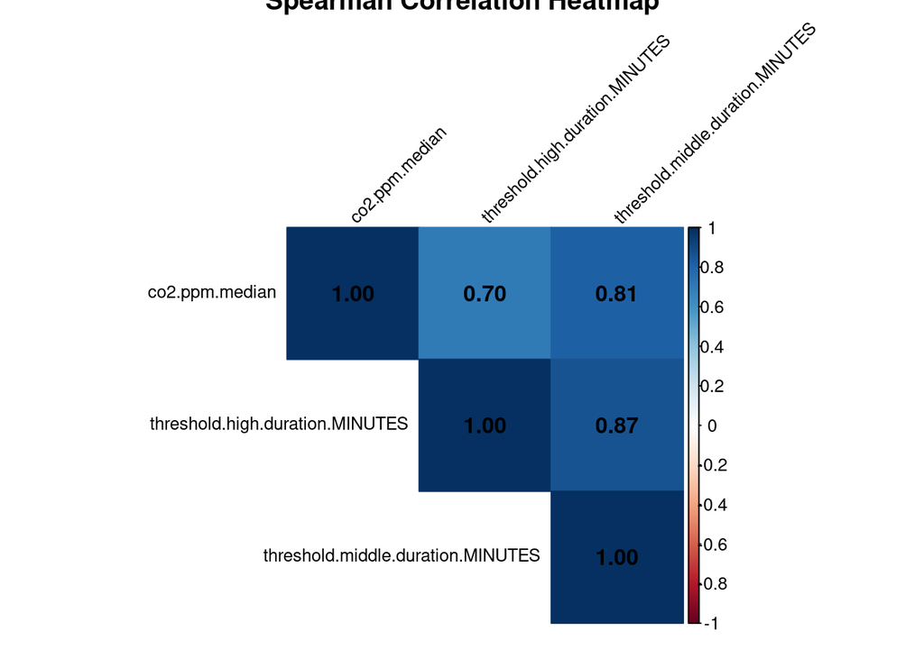

strong correlation between predictors, so they were entered into separate models

Removed NAs and tested distribution of response variable for model parameters

```r
merged_CO2_df_naomit<-na.omit(merged_CO2_df)
```

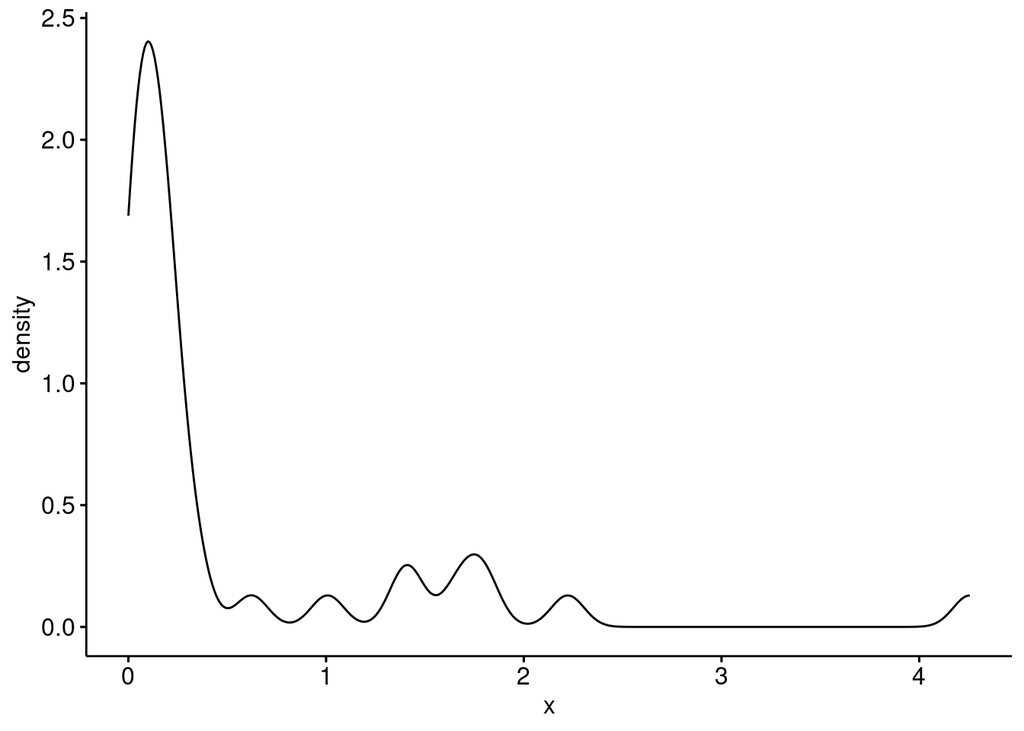

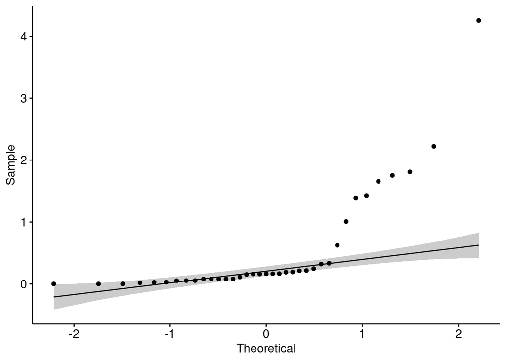

-> Poisson distribution shown by numeric variable, therefore chose Gamma family

## Median of CO2 levels

-> added 1e-3 to assure absence of non-positive values (condition of Gamma family)

```r
PathAbundPH_CO2_mod<-glm(I(PathAbundPH + 1e-3)~co2.ppm.median+school, data= merged_CO2_df_naomit, family = Gamma(link='log'))
summary(PathAbundPH_CO2_mod)
```

```
##
## Call:
## glm(formula = I(PathAbundPH + 0.001) ~ co2.ppm.median + school,
##     family = Gamma(link = "log"), data = merged_CO2_df_naomit)
##
## Coefficients:
##                  Estimate Std. Error t value Pr(>|t|)
## (Intercept)    -2.2802535  0.6527006  -3.494  0.00150 **
## co2.ppm.median  0.0024419  0.0007791   3.134  0.00383 **
## schoolH        -1.0889236  0.5356152  -2.033  0.05098 .
## schoolK        -0.0058891  0.6644898  -0.009  0.99299
## schoolM         1.9860686  0.6090473   3.261  0.00277 **
## schoolR        -0.5874663  0.6189087  -0.949  0.35010
## schoolW        -0.5298589  0.6404168  -0.827  0.41456
## ---
## Signif. codes:  0 '***' 0.001 '**' 0.01 '*' 0.05 '.' 0.1 ' ' 1
##
## (Dispersion parameter for Gamma family taken to be 0.8221262)
##
##     Null deviance: 97.209  on 36  degrees of freedom
## Residual deviance: 51.298  on 30  degrees of freedom
## AIC: -2.9733
##
## Number of Fisher Scoring iterations: 9
```

Plotted result using model residuals with significant effect (median CO2) removed

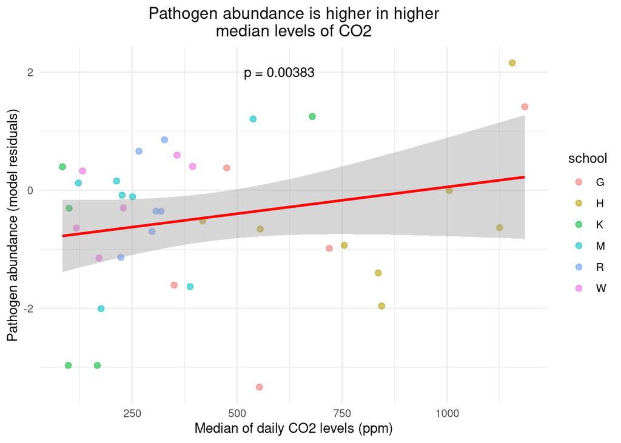

```r
PathAbundPH_CO2_PLOT_mod<-glm(I(PathAbundPH + 1e-3)~school, data= merged_CO2_df_naomit, family = Gamma(link='log'))
PlotPathAbundPH_medianCO2 <- data.frame(
  residuals = residuals(PathAbundPH_CO2_PLOT_mod, type = "deviance")
)
PlotPathAbundPH_medianCO2$CO2median<-merged_CO2_df_naomit$co2.ppm.median
PlotPathAbundPH_medianCO2$school<-merged_CO2_df_naomit$school
```

## High-risk CO2 exposure

This model tests the effect of high-risk CO2 exposure, which is characterized by the duration of time (s) when CO2 levels were measure equal or above high risk levels (1400 ppm)

-> added 1e-3 to assure absence of non-positive values (condition of Gamma family)

```r
PathAbundPH_CO2_high_mod<-glm(I(PathAbundPH + 1e-3)~threshold.high.duration.MINUTES+school, data= merged_CO2_df_naomit, family = Gamma(link='log'))
summary(PathAbundPH_CO2_high_mod)
```

```
##
## Call:
## glm(formula = I(PathAbundPH + 0.001) ~ threshold.high.duration.MINUTES +
##     school, family = Gamma(link = "log"), data = merged_CO2_df_naomit)
##
## Coefficients:
##                                   Estimate Std. Error t value Pr(>|t|)
## (Intercept)                     -1.8756043  0.5086255  -3.688 0.000894 ***
## threshold.high.duration.MINUTES  0.0029109  0.0008548   3.405 0.001897 **
## schoolH                         -0.9619192  0.5272153  -1.825 0.078046 .
## schoolK                          0.3689486  0.6486523   0.569 0.573731
## schoolM                          2.3030023  0.6103932   3.773 0.000710 ***
## schoolR                         -0.2908469  0.6253818  -0.465 0.645239
## schoolW                         -0.4276946  0.6113562  -0.700 0.489577
## ---
## Signif. codes:  0 '***' 0.001 '**' 0.01 '*' 0.05 '.' 0.1 ' ' 1
##
## (Dispersion parameter for Gamma family taken to be 0.8102498)
##
##     Null deviance: 97.209  on 36  degrees of freedom
## Residual deviance: 53.163  on 30  degrees of freedom
## AIC: -1.3784
##
## Number of Fisher Scoring iterations: 10
```

Plotted result using model residuals with significant effect (high-risk CO2 duration) removed

*since the model residuals will be the same as they were in the previous analyses, i simply added the new significant predictor to the dataframe containing the residulas*

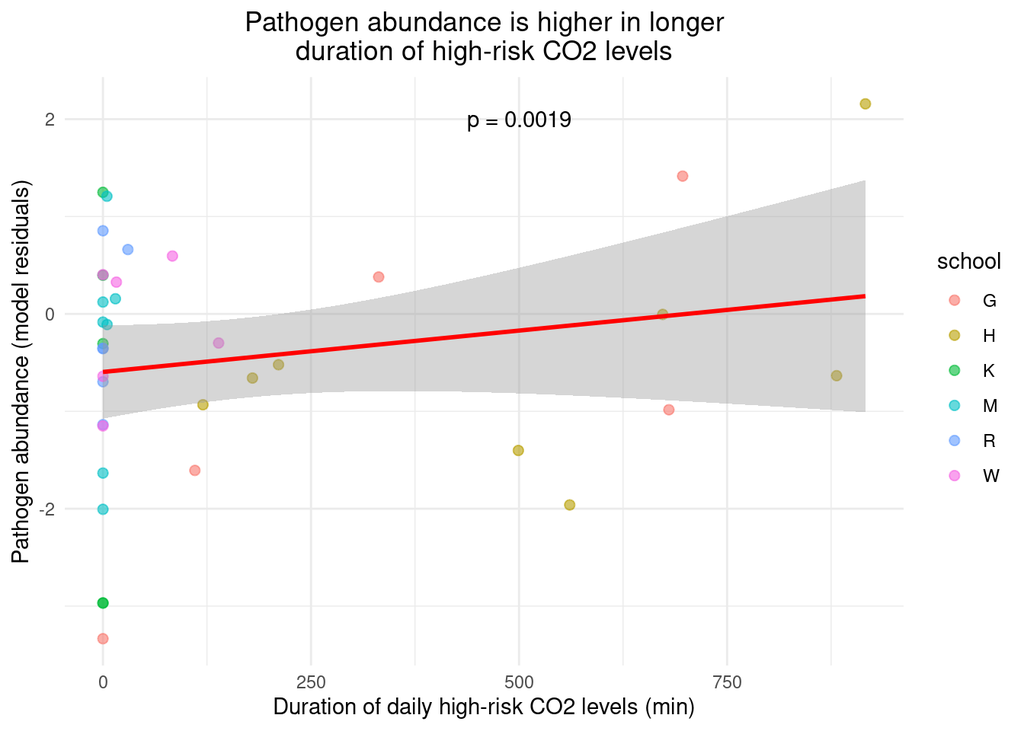

```r
PlotPathAbundPH_medianCO2$highdur<-merged_CO2_df_naomit$threshold.high.duration.MINUTES
```

## Medium-risk CO2 exposure

This model tests the effect of medium-risk CO2 exposure, which is characterized by the duration of time (s) when CO2 levels were measured equal or above medium risk levels (1000 ppm)

-> added 1e-3 to assure absence of non-positive values (condition of Gamma family)

```r
PathAbundPH_CO2_medium_mod<-glm(I(PathAbundPH + 1e-3)~threshold.middle.duration.MINUTES+school, data= merged_CO2_df_naomit, family = Gamma(link='log'))
summary(PathAbundPH_CO2_medium_mod)
```

```
##
## Call:
## glm(formula = I(PathAbundPH + 0.001) ~ threshold.middle.duration.MINUTES +
##     school, family = Gamma(link = "log"), data = merged_CO2_df_naomit)
##
## Coefficients:
##                                     Estimate Std. Error t value Pr(>|t|)
## (Intercept)                       -2.2202374  0.5786450  -3.837 0.000596 ***
## threshold.middle.duration.MINUTES  0.0019766  0.0006006   3.291 0.002558 **
## schoolH                           -0.6371032  0.5549375  -1.148 0.260015
## schoolK                            0.6255915  0.7145854   0.875 0.388279
## schoolM                            2.6402395  0.6803810   3.881 0.000530 ***
## schoolR                           -0.0016863  0.6868333  -0.002 0.998057
## schoolW                           -0.1251575  0.6790214  -0.184 0.855002
## ---
## Signif. codes:  0 '***' 0.001 '**' 0.01 '*' 0.05 '.' 0.1 ' ' 1
##
## (Dispersion parameter for Gamma family taken to be 0.9169696)
##
##     Null deviance: 97.209  on 36  degrees of freedom
## Residual deviance: 52.714  on 30  degrees of freedom
## AIC: -1.7578
##
## Number of Fisher Scoring iterations: 11
```

*since the model residuals will be the same as they were in the previous analyses, i simply added the new significant predictor to the dataframe containing the residulas*

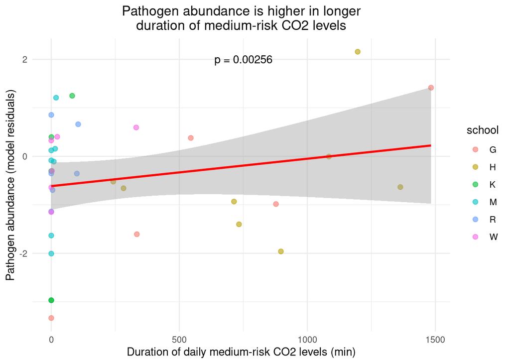

```r
PlotPathAbundPH_medianCO2$middur<-merged_CO2_df_naomit$threshold.middle.duration.MINUTES
```

## Area under CO2 curve

This model tests the effect of total CO2 exposure characterized by the area under the curve for CO2 measurements within 36 hours of the sample upload time

Note: this data was originally merged in with diversity data, so I am now looping in that database.

```r
setwd('~/LuPFiS/CO2')
DIV_CO2auc_df<-read_csv('Richness_CO2auc.csv')
```

```r
DIV_CO2auc_df_naomit<-na.omit(DIV_CO2auc_df)

####Adding PathAbund to test for viral load
setwd('~/LuPFiS/PCRanalyses')
Plotdata <- read.csv("Plotdata.csv")

####exclude tissue samples
Plotdata<-Plotdata[!grepl('T', Plotdata$sample.type), ]

####Excluding bacterial targets as they only serve as positive controls in the setting and typically overload 26k plates
Plotdata<-Plotdata[!grepl('Staphylococcus aureus', Plotdata$Target.Name), ]
Plotdata<-Plotdata[!grepl('Streptococcus pneumoniae', Plotdata$Target.Name), ]

# Group by School and date order
# Calculate the average of Concentration for each subgroup
resultPCR <- Plotdata %>%
  group_by(school, date.order, Target.Name) %>%
  summarise(Average_Concentration = mean(Concentration))
##replace date order of phase 2 schools
Plotdata_df$order<-with(Plotdata_df, ifelse(school %in% c("G", "M", "K"),
                                                    date.order, date.order+8))

###transposing database by creating colums out of values of Target.name
Plotdata_transposed_df <- Plotdata_df %>%
  arrange(school, date.order) %>%
  pivot_wider(
    names_from = Target.Name,
    values_from = Average_Concentration)

Abund_df <- Plotdata_transposed_df %>%
  mutate(PathAbund = rowSums(across(c("Adenovirus", "Enterovirus", "Influenza A", "Influenza B",
                                      "Norovirus", "RSV", "Rhinovirus", "SARS-CoV-2")), na.rm = TRUE))

#Unifying columns between auc df and abund df for merging
Abund_df <- Abund_df %>%
  select(-order) %>%
  rename(order = date.order)

Abund_df_merge<-Abund_df%>%
  select(school, order, PathAbund)

DIV_CO2auc_df<-DIV_CO2auc_df%>%
  left_join(Abund_df_merge, by = c('school', 'order'))


##Model for abundance vs auc
DIV_CO2auc_df_naomit<-na.omit(DIV_CO2auc_df)

###PathAbund is still Poisson from the previous analyses, so model uses poisson family
##Viral diversity analyses revealed sample type has no effect on richness, only school, so that is the only co-variant to correct model
CO2_abund_auc_mod<-glm(I(PathAbund + 1e-3)~auc+school, data= DIV_CO2auc_df_naomit, family = poisson(link='log'))
warnings()
summary(CO2_abund_auc_mod)
```

```
##
## Call:
## glm(formula = I(PathAbund + 0.001) ~ auc + school, family = poisson(link = "log"),
##     data = DIV_CO2auc_df_naomit)
##
## Coefficients:
##               Estimate Std. Error z value Pr(>|z|)
## (Intercept) -1.038e+00  9.274e-01  -1.120   0.2628
## auc          1.060e-08  5.316e-09   1.995   0.0461 *
## schoolH     -3.135e-01  6.334e-01  -0.495   0.6206
## schoolK     -6.117e-01  1.226e+00  -0.499   0.6179
## schoolM      1.366e+00  8.966e-01   1.523   0.1277
## schoolR      8.948e-01  8.552e-01   1.046   0.2954
## schoolW     -1.101e+00  1.767e+00  -0.623   0.5332
## ---
## Signif. codes:  0 '***' 0.001 '**' 0.01 '*' 0.05 '.' 0.1 ' ' 1
##
## (Dispersion parameter for poisson family taken to be 1)
##
##     Null deviance: 33.652  on 24  degrees of freedom
## Residual deviance: 22.450  on 18  degrees of freedom
## AIC: Inf
##
## Number of Fisher Scoring iterations: 5
```

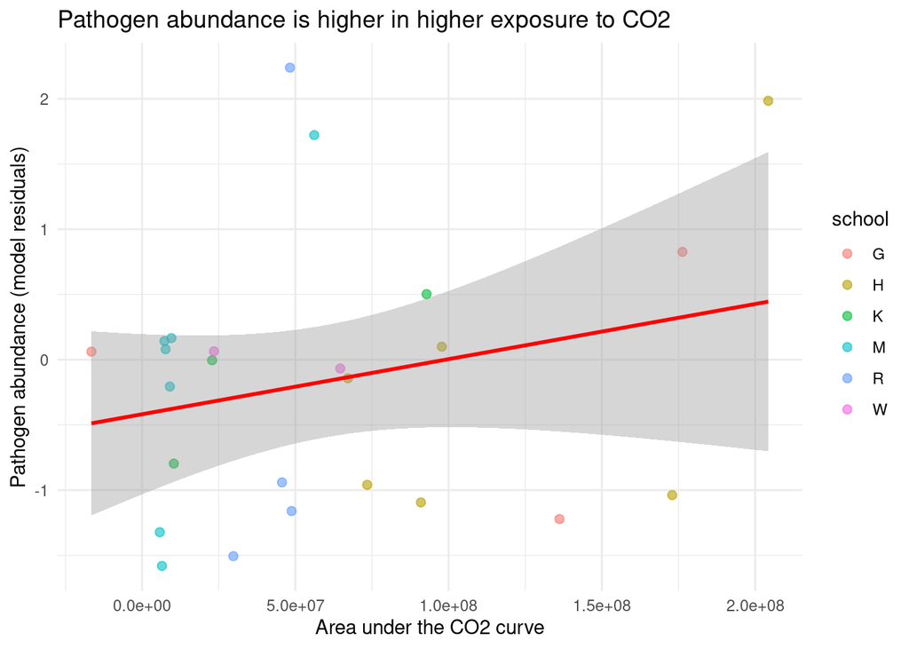

```r
##Plot significant result for auc
CO2_abund_auc_PLOT_mod<-glm(I(PathAbund + 1e-3)~school, data= DIV_CO2auc_df_naomit, family = poisson(link='log'))
PlotCO2_Abund_auc <- data.frame(
  residuals = residuals(CO2_abund_auc_PLOT_mod, type = "deviance")
)
PlotCO2_Abund_auc$auc<-DIV_CO2auc_df_naomit$auc
PlotCO2_Abund_auc$school<-DIV_CO2auc_df_naomit$school
ggplot(PlotCO2_Abund_auc, aes(x = auc, y = residuals, color=school)) +
  geom_point(alpha = 0.6, size=2) +
  geom_smooth(method = "lm", se = TRUE, color = "red") +
  theme_minimal() +
  labs(
    x = "Area under the CO2 curve",
    y = "Pathogen abundance (model residuals)",
    title = "Pathogen abundance is higher in higher exposure to CO2"
  )
```